##### AI TECH - Akademia Innowacyjnych Zastosowań Technologii Cyfrowych. Programu Operacyjnego Polska Cyfrowa na lata 2014-2020

# Przykład 2 DO LABORATORIUM 5

# Tomasz Neumann

### Klasyfikacja przy użyciu Keras i Tensorflow - Autoenkoder

[figure not shown]

Projekt współfinansowany ze środków Unii Europejskiej w ramach Europejskiego Funduszu Rozwoju Regionalnego Program Operacyjny Polska Cyfrowa na lata 2014-2020, Oś Priorytetowa nr 3 "Cyfrowe kompetencje społeczeństwa" Działanie nr 3.2 "Innowacyjne rozwiązania na rzecz aktywizacji cyfrowej" Tytuł projektu: „Akademia Innowacyjnych Zastosowań Technologii Cyfrowych (AI Tech)”

# 5. Przykład 2

Autokodery to modele sieci neuronowej złożone z dwóch bloków:

- kodera
- dekodera

które przetwarzając dane wejściowe $x$, dążą do ich rekonstrukcji na wyjściu $\hat x$. Związany jest z tym również termin "auto".

W klasycznym ujęciu autokodery działają na danych wejściowych X bez wyróżniania etykiet y. Rozpatrywany problem polega zatem na nauczeniu modelu takich wag, aby uzyskać idealną rekonstrukcję. Ponieważ nie rozważamy wykorzystania etykiet czy innej formy nadzoru, dlatego klasyczne autokodery zaliczane są do grupy uczenia nienadzorowanego. Należy jednak podkreślić, że znane są również prace w zakresie autokoderów z nadzorem (ang. Supervised AutoEncoders SAE), których celem jest rekonstrukcja zarówno danych wejściowych jak i etykiet.

Rolą kodera jest transformacja $L$ wymiarowych danych wejściowych ($L$ - liczba cech, danych surowych, itp.) do $E$ wymiarowych, nowych cech ($E<L$). Transformacja reprezentacji danych musi być tak dokonana, aby dekoder mógł zrekonstruować dane w zmienionej reprezentacji na dane jak najbardziej podobne do reprezentacji źródłowej. Kryterium podobieństwa wyznaczać będzie funkcja kosztu, np.:

$$L=||\textbf x- \hat {\textbf x}||^2$$

Stosując model MLP, blok kodera można zapisać jako:

$$ \textbf z = a(\textbf W^{(k)} \textbf x^{(k)})$$ natomiast blok dekodera jako:

$$ \hat {\textbf x} = a(\textbf W^{(d)} \textbf z^{(d)})$$

gdzie: $a()$ - to funkcja aktywacji, $W$ - parametry modelu (z lub bez obciążenia $W_0$), $x$ - dane wejsciowe (z lub bez $x_0=1$).

Do celów tego przykładu użyjemy zbiór danych MNIST Fashion. Na wzór znanego zbioru zeskanowanych cyfr MNIST utworzono zbiór danych MNIST Fashion zawierający 70 000 obrazów (60000 z. treningowy + 10000 z. testowy) o rozdzielczości 28x28 pikseli, każdy przedstawiający zdjęcie odzieży należące do jednej z 10 klas:

0 T-shirt/top, 1 Trouser, 2 Pullover, 3 Dress, 4 Coat, 5 Sandal, 6 Shirt, 7 Sneaker, 8 Bag, 9 Ankle boot

Oryginalny zbiór dostępny jest na stronie: https://github.com/zalandoresearch/fashion-mnist (The MIT License (MIT) Copyright © [2017] Zalando)

Zastosowanie zbioru zrealizowane zostanie poprzez dostępne API w TensorFlow.

```python
import numpy as np
import tensorflow as tf
import matplotlib.pyplot as plt
import matplotlib

print(tf.__version__)

(X_train, y_train), (X_test, y_test) = tf.keras.datasets.fashion_mnist.load_data()

X_train = X_train.astype('float32') / 255.0
X_test = X_test.astype('float32') / 255.0

print (X_train.shape)
print (X_test.shape)
```

```
2.21.0
(60000, 28, 28)
(10000, 28, 28)
```

```
Bag
```

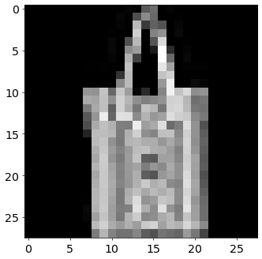

```python
labels = ["T-shirt/top", "Trouser", "Pullover", "Dress", "Coat", "Sandalv",
          "Shirt", "Sneaker", "Bag", "Ankle boot"]
example = 57
print(labels[y_train[example]])

matplotlib.rcParams.update({'font.size': 16})
fig = plt.figure(figsize=(9, 6), dpi=64)
plt.imshow(X_train[example], cmap='gray')
plt.show()
```

Zrealizujemy teraz model autokodera, który będzie zmieniał reprezentację danych do nowej $E$ wymiarowej przestrzeni ukrytej. Wprowadzona zostanie zmienna latent_space_dim do określenia wymiaru $E$ (będzie można eksperymentować z wpływem doboru rozmiaru reprezentacji danych w przestrzeni ukrytej na wyniki autokodera).

Jeśli $E < L$ (liczba cech zbioru oryginalnego) mówimy o niekompletnych autokoderach (ang. undercomplete autoencoders).

Jeśli $E > L$ mówimy o nadkompletnych autokoderach (ang. overcomplete autoencoders), często związanych z danymi reprezentowanymi w warstwie ukrytej w sposób rzadki (dużo zer - wiele neuronów nieaktywnych) - ang. sparse autoencoders.

Przeanazlizujmy aktualnie przypadek, gdzi $E<L$.

```python
from tensorflow.keras import layers, losses

class AE(tf.keras.models.Model):
  def __init__(self, data_shape, lat_dim, enc_act, dec_act):
    super(AE, self).__init__()
    self.latent_space_dim = lat_dim

    self.encoder = tf.keras.Sequential([
      # Kształt danych (60000, 28, 28), więc dokonywane jest ich spłaszczenie
      layers.Flatten(),
      layers.Dense(latent_space_dim, activation=enc_act)
    ])

    self.decoder = tf.keras.Sequential([
      # Kształt danych (60000, 28, 28), a na wyjściu oczekujemy 28*28
      layers.Dense(data_shape[1]*data_shape[2], activation=dec_act),
      layers.Reshape((data_shape[1],data_shape[2]))
    ])

  # forward projection
  def call(self, x):
    z = self.encoder(x)
    x_e = self.decoder(z)
    return x_e
```

```python
latent_space_dim = 16
encoder_activation = 'relu'
decoder_activation = 'sigmoid'
epochs = 10
print(X_train.shape)

ae = AE(X_train.shape, latent_space_dim, encoder_activation, decoder_activation)
ae.compile(optimizer='adam', loss=losses.MeanSquaredError(), metrics=['accuracy'])
history = ae.fit(X_train, X_train, epochs=epochs, shuffle=True,
       validation_data=(X_test, X_test))
```

```
(60000, 28, 28)
WARNING:tensorflow:TensorFlow GPU support is not available on native Windows for TensorFlow >= 2.11. Even if CUDA/cuDNN are installed, GPU will not be used. Please use WSL2 or the TensorFlow-DirectML plugin.
1875/1875 ━━━━━━━━━━━━━━━━━━━━ 7s 3ms/step - accuracy: 0.0895 - loss: 0.0335 - val_accuracy: 0.1025 - val_loss: 0.0212
1875/1875 ━━━━━━━━━━━━━━━━━━━━ 5s 3ms/step - accuracy: 0.1082 - loss: 0.0192 - val_accuracy: 0.1083 - val_loss: 0.0184
1875/1875 ━━━━━━━━━━━━━━━━━━━━ 6s 3ms/step - accuracy: 0.1124 - loss: 0.0181 - val_accuracy: 0.1135 - val_loss: 0.0179
1875/1875 ━━━━━━━━━━━━━━━━━━━━ 6s 3ms/step - accuracy: 0.1140 - loss: 0.0178 - val_accuracy: 0.1150 - val_loss: 0.0178
1875/1875 ━━━━━━━━━━━━━━━━━━━━ 6s 3ms/step - accuracy: 0.1147 - loss: 0.0177 - val_accuracy: 0.1164 - val_loss: 0.0177
1875/1875 ━━━━━━━━━━━━━━━━━━━━ 6s 3ms/step - accuracy: 0.1148 - loss: 0.0176 - val_accuracy: 0.1154 - val_loss: 0.0176
1875/1875 ━━━━━━━━━━━━━━━━━━━━ 6s 3ms/step - accuracy: 0.1152 - loss: 0.0175 - val_accuracy: 0.1157 - val_loss: 0.0175
1875/1875 ━━━━━━━━━━━━━━━━━━━━ 10s 3ms/step - accuracy: 0.1150 - loss: 0.0175 - val_accuracy: 0.1148 - val_loss: 0.0175
1875/1875 ━━━━━━━━━━━━━━━━━━━━ 6s 3ms/step - accuracy: 0.1152 - loss: 0.0174 - val_accuracy: 0.1153 - val_loss: 0.0176
1875/1875 ━━━━━━━━━━━━━━━━━━━━ 6s 3ms/step - accuracy: 0.1153 - loss: 0.0174 - val_accuracy: 0.1152 - val_loss: 0.0174
```

W celu ilustracji działania zastosujmy koder i dekoder dla zbioru testowego.

```python
img_encoded = ae.encoder(X_test).numpy()
img_decoded = ae.decoder(img_encoded).numpy()
```

Zilustrujmy następnie obraz oryginalny oraz zrekonstruowany przez autokoder.

```
Wejściowy rozmiar obrazu (shape): (28, 28)
Rozmiar warstwy ukrytej (shape): (16,)
Etykieta dla przykładu: Trouser
```

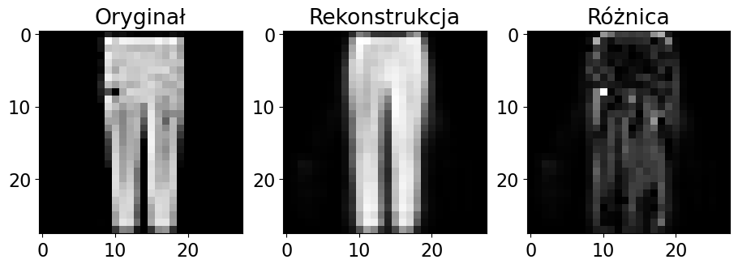

```python
example = 200

print("Wejściowy rozmiar obrazu (shape):", X_test[example].shape)
print("Rozmiar warstwy ukrytej (shape):", img_encoded[example].shape)

print("Etykieta dla przykładu:", labels[y_test[example]])

matplotlib.rcParams.update({'font.size': 16})
fig, (ax1, ax2, ax3) = plt.subplots(1, 3, figsize=(11,11))

ax1.set_title("Oryginał")
ax1.imshow(X_test[example], cmap='gray')

ax2.set_title("Rekonstrukcja")
ax2.imshow(img_decoded[example], cmap='gray')

ax3.set_title("Różnica")
ax3.imshow(np.abs(img_decoded[example]-X_test[example]), cmap='gray')
plt.show()
```

Można zaobserwować efekt wygładzenia obrazu (wygładzenie to filtracja dolnoprzepustowa - zmniejszamy częstotliwości przestrzenne, czyli liczbę zmian wartości pikseli na jednostkę długości).

Oczywiste staje się wówczas pytanie, czy moglibyśmy zastosować wyuczony autokoder do odszumiania obrazów.

Wygenerujemy obraz z szumem i zastosujmy ten sam model, który trenowaliśmy wyżej.

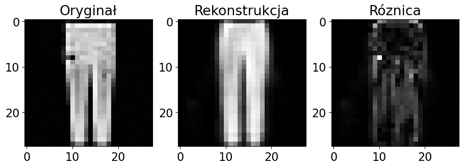

```python
noise_amp = 0.003
noise = noise_amp * np.random.normal(size=(28,28))
img_example = np.array(X_test[example] + noise).reshape((1,28,28))


img_example_encoded = ae.encoder(img_example).numpy()
img_example_decoded = ae.decoder(img_example_encoded).numpy()

matplotlib.rcParams.update({'font.size': 16})
fig, (ax1, ax2, ax3) = plt.subplots(1, 3, figsize=(11,11))

ax1.set_title("Oryginał")
ax1.imshow(img_example[0], cmap='gray')

ax2.set_title("Rekonstrukcja")
ax2.imshow(img_example_decoded[0], cmap='gray')

ax3.set_title("Róznica")
ax3.imshow(np.abs(img_example_decoded[0]-img_example[0]), cmap='gray')
plt.show()
```

Autokodery mogą być zastosowane nie tylko do obrazów ale również do sekwencji danych, sygnałów, danych 3D, itd.

# Zadania do wykonania

**Zadanie 1**

Przeprojektuj model dla danych wejściowych zbioru cyfr MNIST oraz wykonaj test odszumiania obrazu dla cyfry będącej ostatnią cyfrą w Twoim numerze albumu.

## Rozwiązanie zadania 1

Numer albumu: `193257`

Cyfra do testu odszumiania: `7`.

Model z przykładu przerobiłem na dane MNIST: wejście ma rozmiar `28x28`, koder spłaszcza obraz i zapisuje go w przestrzeni ukrytej o rozmiarze `32`, a dekoder rekonstruuje obraz z powrotem do `28x28`.

```
Testowana cyfra: 7
Wymiar przestrzeni ukrytej: 32
Liczba epok: 6, batch_size: 128
Końcowy loss treningowy: 0.0116
Końcowy loss walidacyjny: 0.0109
Rekonstrukcja całego zbioru testowego - MSE: 0.0109, MAE: 0.0388
Wybrany indeks testowy cyfry 7: 0
Szum gaussowski, odchylenie standardowe: 0.35
MSE przed odszumianiem: 0.0634
MSE po odszumianiu: 0.0462
MAE przed odszumianiem: 0.1506
MAE po odszumianiu: 0.0729
Poprawa MSE: 27.15%
Poprawa MAE: 51.60%
```

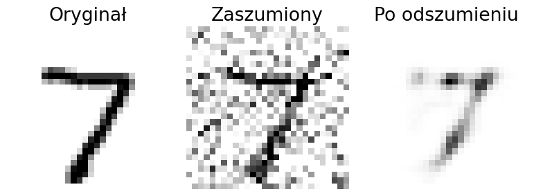

```python
from pathlib import Path
import random

import numpy as np
import matplotlib.pyplot as plt
import tensorflow as tf
from tensorflow.keras import layers, losses

SEED = 42
random.seed(SEED)
np.random.seed(SEED)
tf.random.set_seed(SEED)

album_number = "193257"
last_digit = int(album_number[-1])
latent_space_dim = 32
epochs = 6
batch_size = 128
noise_amp = 0.35

mnist_path = Path.home() / ".keras" / "datasets" / "mnist.npz"
with np.load(mnist_path) as data:
    X_train = data["x_train"].astype("float32") / 255.0
    y_train = data["y_train"].astype(np.uint8)
    X_test = data["x_test"].astype("float32") / 255.0
    y_test = data["y_test"].astype(np.uint8)


class AE(tf.keras.Model):
    def __init__(self, lat_dim):
        super().__init__()
        self.encoder = tf.keras.Sequential(
            [
                layers.Flatten(input_shape=(28, 28)),
                layers.Dense(lat_dim, activation="relu"),
            ]
        )
        self.decoder = tf.keras.Sequential(
            [
                layers.Dense(784, activation="sigmoid"),
                layers.Reshape((28, 28)),
            ]
        )

    def call(self, x):
        encoded = self.encoder(x)
        decoded = self.decoder(encoded)
        return decoded


ae = AE(latent_space_dim)
ae.compile(optimizer="adam", loss=losses.MeanSquaredError())
history = ae.fit(
    X_train,
    X_train,
    epochs=epochs,
    batch_size=batch_size,
    validation_data=(X_test, X_test),
    verbose=0,
)

decoded_test = ae.predict(X_test, verbose=0)
reconstruction_mse = np.mean((X_test - decoded_test) ** 2)
reconstruction_mae = np.mean(np.abs(X_test - decoded_test))

digit_index = int(np.flatnonzero(y_test == last_digit)[0])
rng = np.random.default_rng(SEED)
noise = rng.normal(loc=0.0, scale=noise_amp, size=X_test[digit_index].shape).astype(np.float32)
noisy_digit = np.clip(X_test[digit_index] + noise, 0, 1)
denoised_digit = ae.predict(noisy_digit.reshape(1, 28, 28), verbose=0)[0]

noisy_mse = np.mean((X_test[digit_index] - noisy_digit) ** 2)
denoised_mse = np.mean((X_test[digit_index] - denoised_digit) ** 2)
noisy_mae = np.mean(np.abs(X_test[digit_index] - noisy_digit))
denoised_mae = np.mean(np.abs(X_test[digit_index] - denoised_digit))

print(f"Testowana cyfra: {last_digit}")
print(f"Wymiar przestrzeni ukrytej: {latent_space_dim}")
print(f"Liczba epok: {epochs}, batch_size: {batch_size}")
print(f"Końcowy loss treningowy: {history.history['loss'][-1]:.4f}")
print(f"Końcowy loss walidacyjny: {history.history['val_loss'][-1]:.4f}")
print(f"Rekonstrukcja całego zbioru testowego - MSE: {reconstruction_mse:.4f}, MAE: {reconstruction_mae:.4f}")
print(f"Wybrany indeks testowy cyfry {last_digit}: {digit_index}")
print(f"Szum gaussowski, odchylenie standardowe: {noise_amp}")
print(f"MSE przed odszumianiem: {noisy_mse:.4f}")
print(f"MSE po odszumianiu: {denoised_mse:.4f}")
print(f"MAE przed odszumianiem: {noisy_mae:.4f}")
print(f"MAE po odszumianiu: {denoised_mae:.4f}")
print(f"Poprawa MSE: {(1 - denoised_mse / noisy_mse) * 100:.2f}%")
print(f"Poprawa MAE: {(1 - denoised_mae / noisy_mae) * 100:.2f}%")

fig, axes = plt.subplots(1, 3, figsize=(8, 3))
axes[0].imshow(X_test[digit_index], cmap="binary")
axes[0].set_title("Oryginał")
axes[1].imshow(noisy_digit, cmap="binary")
axes[1].set_title("Zaszumiony")
axes[2].imshow(denoised_digit, cmap="binary")
axes[2].set_title("Po odszumieniu")
for axis in axes:
    axis.axis("off")
plt.tight_layout()
plt.show()
```

**Wnioski - zadanie 1**

Po zmianie danych wejściowych na MNIST autokoder z przestrzenią ukrytą `32` po `6` epokach uzyskał końcowy błąd treningowy `0.0116` i walidacyjny `0.0109`. Rekonstrukcja całego zbioru testowego miała `MSE=0.0109` i `MAE=0.0388`, więc model odtwarzał cyfry w uproszczonej, ale rozpoznawalnej postaci.

Dla cyfry `7`, (ostatnia cyfra indeksu), dodany szum dał `MSE=0.0634` i `MAE=0.1506`. Po przejściu przez autokoder błąd spadł do `MSE=0.0462` i `MAE=0.0729`, czyli poprawa wyniosła `27.15%` dla MSE oraz `51.60%` dla MAE. W tym teście autokoder faktycznie zmniejszył szum, ale rekonstrukcja nie jest idealna, realnie trudniej jest odróżnić cyfrę oryginalną niż po odszumieniu, doszło tutaj do utraty inforamcji.